# Effects of urban green infrastructure on supply provision of ecosystem service: Temperature reduction

```r
gam_SUVI_cat <- gam(T_mean ~ s(SUVI, by = Category), data = cdata, method = "ML")
AIC(gam_SUVI_cat)
```

```
## [1] 561438.4
```

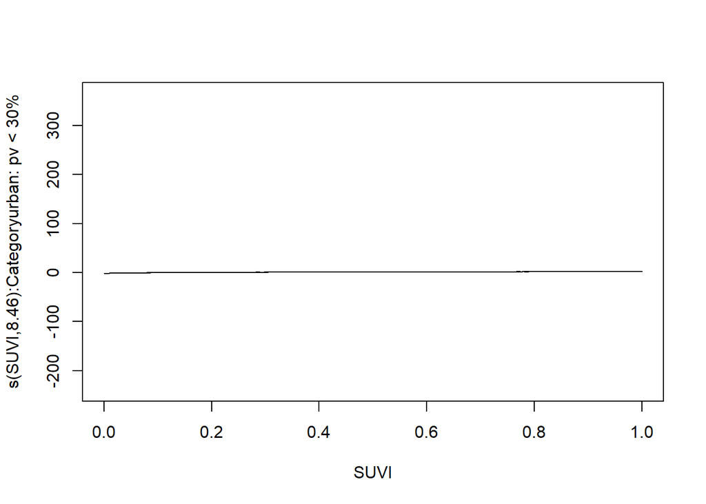

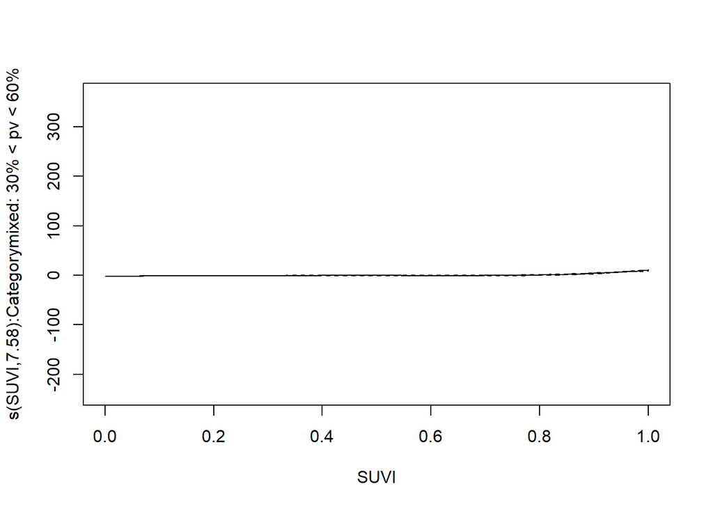

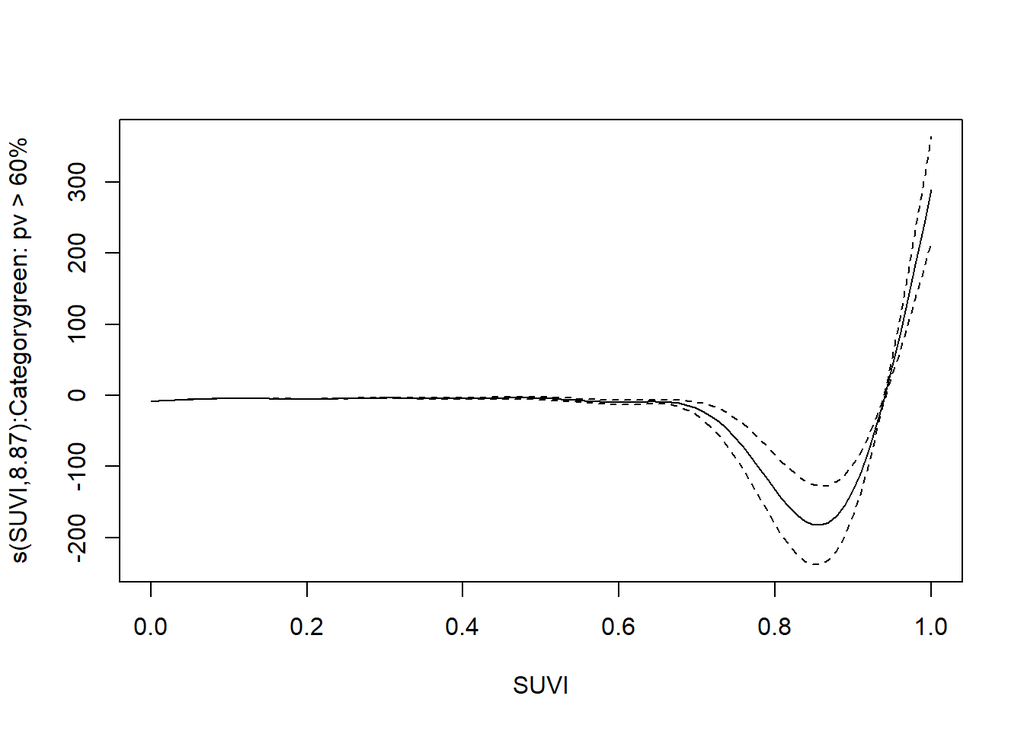

```r
plot(gam_SUVI_cat, all.terms = TRUE)
```

```r
gam_SGVI_cat <- gam(T_mean ~ s(SGVI, by = Category), data = cdata, method = "ML")
AIC(gam_SGVI_cat)
```

```
## [1] 568823.1
```

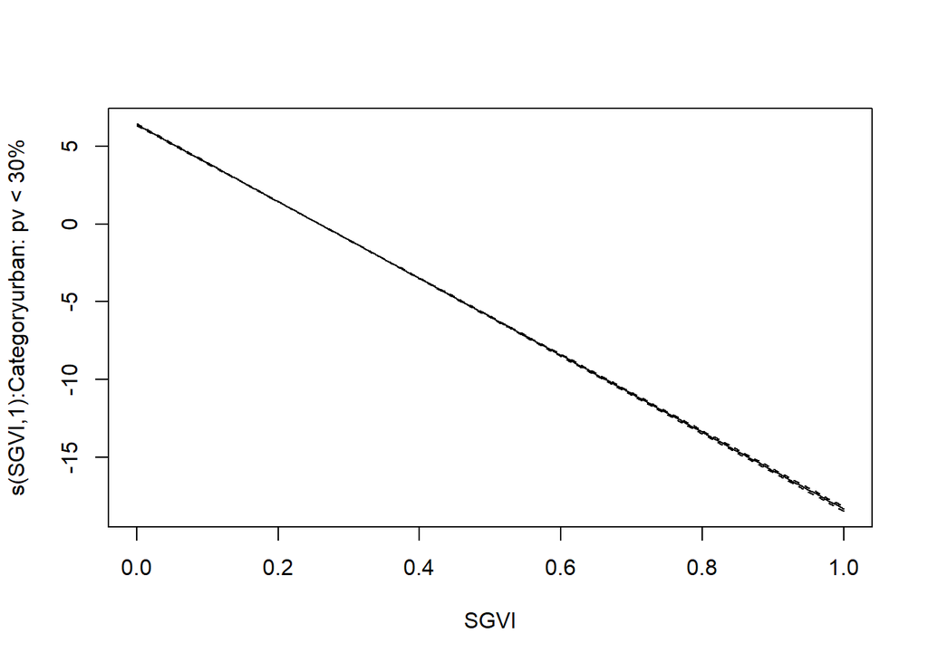

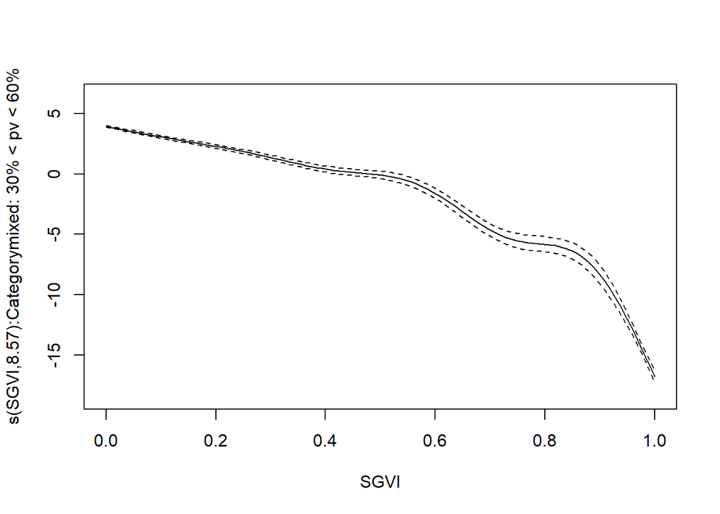

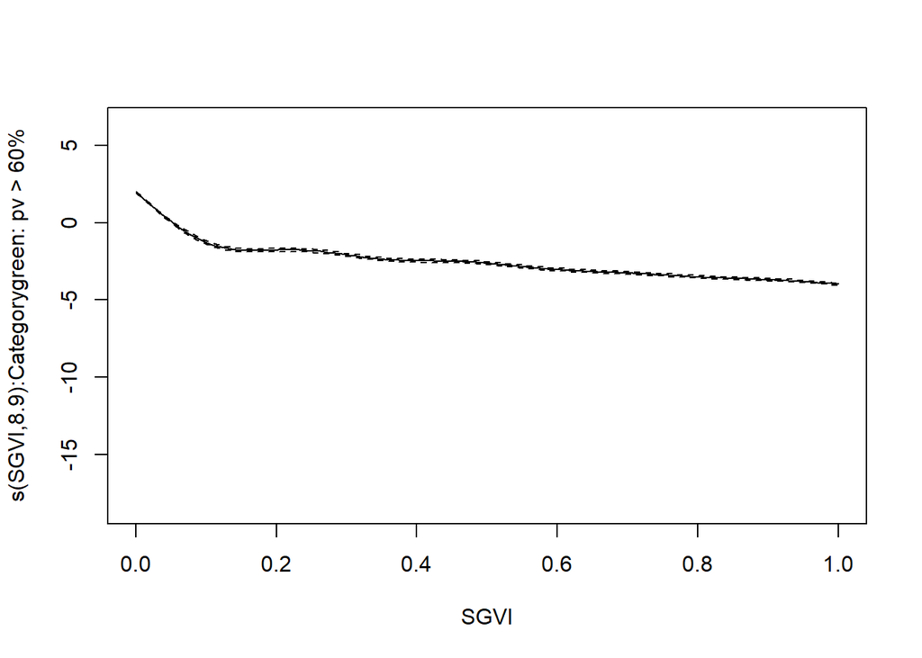

```r
plot(gam_SGVI_cat, all.terms = TRUE)
```

```r
gam_multi <- gam(T_mean ~ s(SVI, prop_veg), data = cdata, method = "ML")
AIC(gam_multi)
```

```
## [1] 539115.1
```

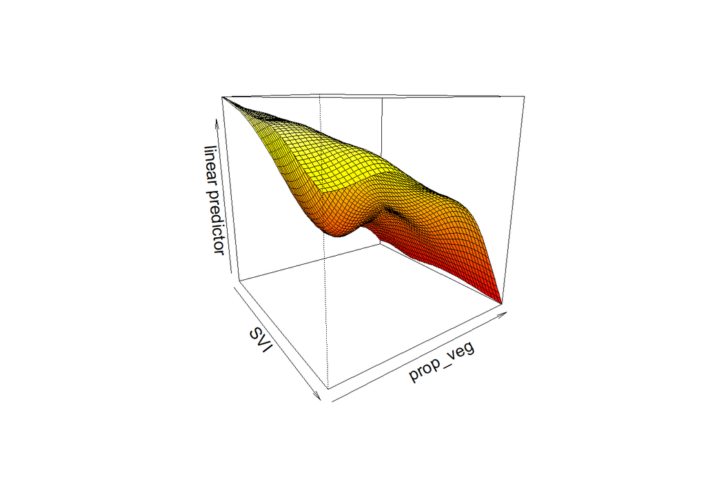

```r
vis.gam(gam_multi, view = c("SVI", "prop_veg"),
    theta = 55, n.grid = 50, lwd = 0.4)
```

SVI lowers temperature in places with low proportion of vegetation!

Just to finish it up real nice to see if i can do it its PCA

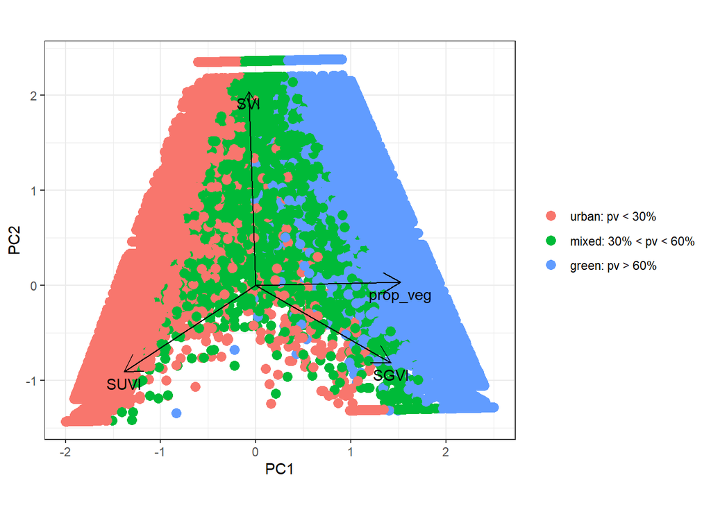

```r
library(vegan)

Y <- scale(as.data.frame(cdata)[, "T_mean"])  # Response variable, scaled
X <- scale(as.data.frame(cdata)[, predictors[-1]])

Y <- as.data.frame(Y)
X <- as.data.frame(X)

pca_result <- prcomp(X, center = TRUE, scale = TRUE)

cdata$PC1 <- pca_result$x[, "PC1"]
cdata$PC2 <- pca_result$x[, "PC2"]

# Extract loadings
loadings_df <- as.data.frame(pca_result$rotation)
loadings_df$Variable <- rownames(pca_result$rotation)

ggplot() +
  geom_point(data = cdata, aes(x = PC1, y = PC2, color = Category), size = 3) +
  geom_segment(data = loadings_df, aes(x = 0, y = 0, xend = PC1 * max(abs(cdata$PC1)), yend = PC2 * max(abs(cdata$PC2))),
               arrow = arrow(length = unit(0.2, "inches")), color = "black") +
  geom_text(data = loadings_df, aes(x = PC1 * max(abs(cdata$PC1)), y = PC2 * max(abs(cdata$PC2)), label = Variable), vjust = 1.5, color = "black") +
  theme_bw() +
  labs(title = element_blank(), x = "PC1", y = "PC2") +
  theme(legend.title = element_blank()) +
  coord_fixed()  # Ensures the plot is square
```

There is two principal components in this analysis, one related to proportion of vegetation, SGVI and SUVI and another more related to SVI that together compose separate variables.

we need to check if now the linear model looks fancy and good.

```r
rda_result <- rda(Y ~ ., data = as.data.frame(cdata)[,predictors[-1]])

fwd.sel <- ordiR2step(rda(Y ~ 1, data = X), # lower model limit (simple!)
               scope = formula(rda_result), # upper model limit (the "full" model)
               direction = "forward",
               R2scope = TRUE, # can't surpass the "full" model's R2
               pstep = 1000,
               trace = FALSE) # change to TRUE to see the selection process!

fwd.sel$call # all vars were kept
```

```
## rda(formula = Y ~ prop_veg + SGVI + SUVI + SVI, data = X)
```

```r
rda_result$CCA$biplot
```

```
##                 RDA1
## SVI       0.08992853
## SGVI     -0.89105415
## SUVI      0.82844803
## prop_veg -0.99575810
```

```r
RsquareAdj(rda_result)
```

```
## $r.squared
## [1] 0.8148043
##
## $adj.r.squared
## [1] 0.8147983
```

```r
anova.cca(rda_result, step = 1000, by = "term")
```

```
## Permutation test for rda under reduced model
## Terms added sequentially (first to last)
## Permutation: free
## Number of permutations: 999
##
## Model: rda(formula = Y ~ SVI + SGVI + SUVI + prop_veg, data = as.data.frame(cdata)[, predictors[-1]])
##              Df Variance        F Pr(>F)
## SVI           1  0.00659   4394.1  0.001 ***
## SGVI          1  0.73083 487340.5  0.001 ***
## SUVI          1  0.00394   2626.9  0.001 ***
## prop_veg      1  0.07345  48978.6  0.001 ***
## Residual 123495  0.18520
## ---
## Signif. codes:  0 '***' 0.001 '**' 0.01 '*' 0.05 '.' 0.1 ' ' 1
```

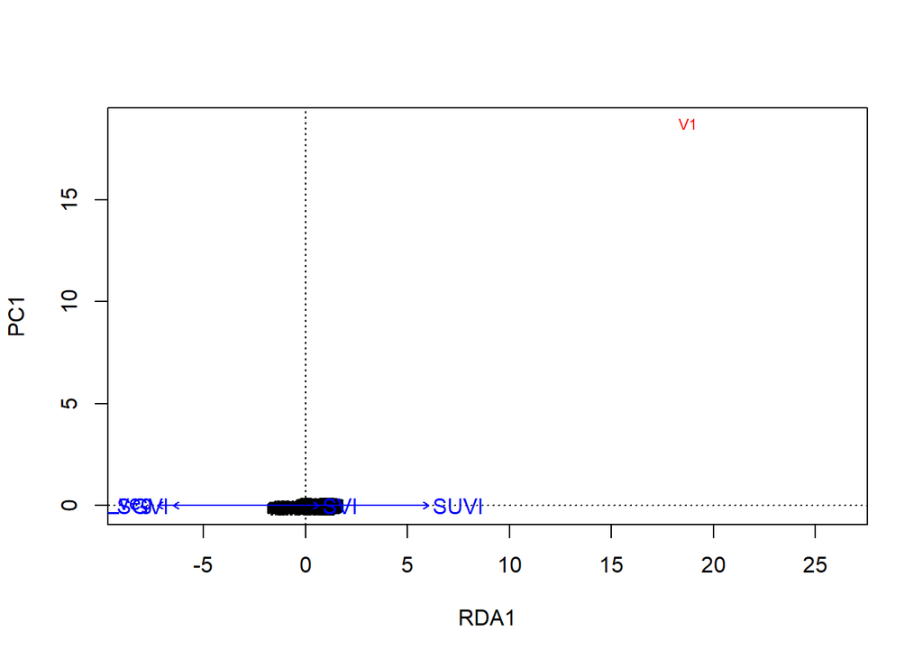

```r
# Type 1 scaling
ordiplot(rda_result, scaling = 1, type = "text")
```

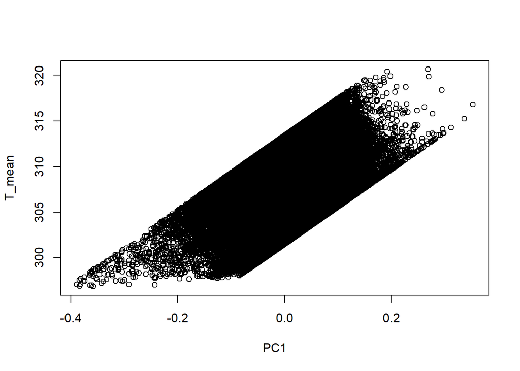

```r
# Assuming 'grid_sf' is your spatial data read from a shapefile
cdata$RDA1 <- scores(rda_result, display = "sites")[,1]  # Adding the first RDA axis scores to the spatial data
cdata$PC1 <- scores(rda_result, display = "sites")[,2]  # Adding the second RDA axis scores to the spatial data

plot(T_mean ~ PC1, cdata)
```

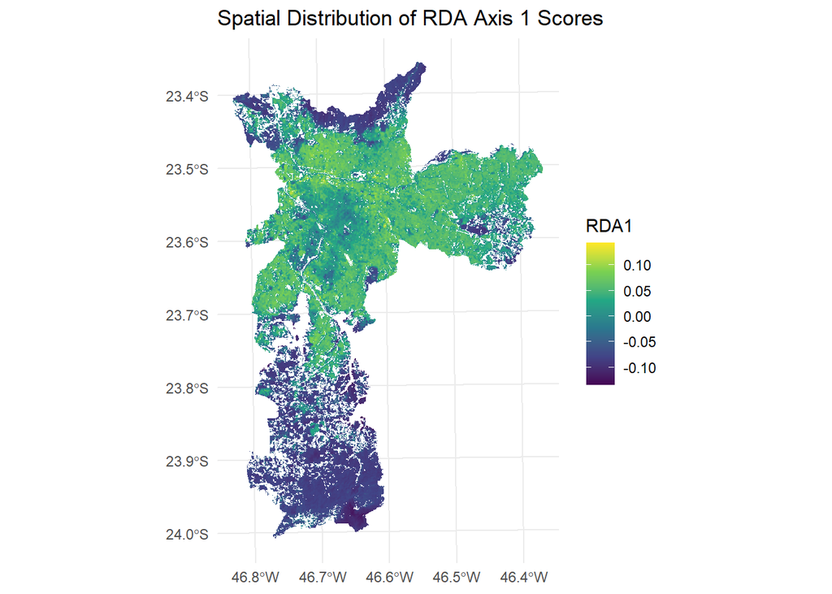

```r
ggplot(cdata) +
  geom_sf(aes(fill = RDA1), color = NA) +  # Fill grid cells based on RDA1 scores
  scale_fill_viridis_c() +  # Use a continuous color scale
  labs(title = "Spatial Distribution of RDA Axis 1 Scores") +
  theme_minimal()
```

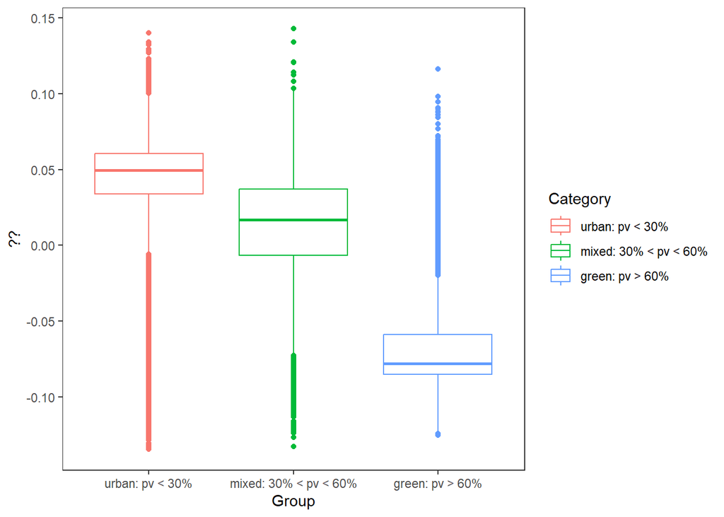

```r
ggplot(cdata, aes(x = Category, y = RDA1, color = Category)) +
  geom_boxplot() +
  theme_minimal() +
  theme_bw() +
  theme(plot.title = element_blank(),
        panel.grid.major = element_blank(),
        panel.grid.minor = element_blank()) +
  labs(title = "Box Plot of PC1 Scores by Group", x = "Group", y = "??")
```

```r
anova(rda_result)
```

```
## Permutation test for rda under reduced model
## Permutation: free
## Number of permutations: 999
##
## Model: rda(formula = Y ~ SVI + SGVI + SUVI + prop_veg, data = as.data.frame(cdata)[, predictors[-1]])
##              Df Variance      F Pr(>F)
## Model         4   0.8148 135835  0.001 ***
## Residual 123495   0.1852
## ---
## Signif. codes:  0 '***' 0.001 '**' 0.01 '*' 0.05 '.' 0.1 ' ' 1
```

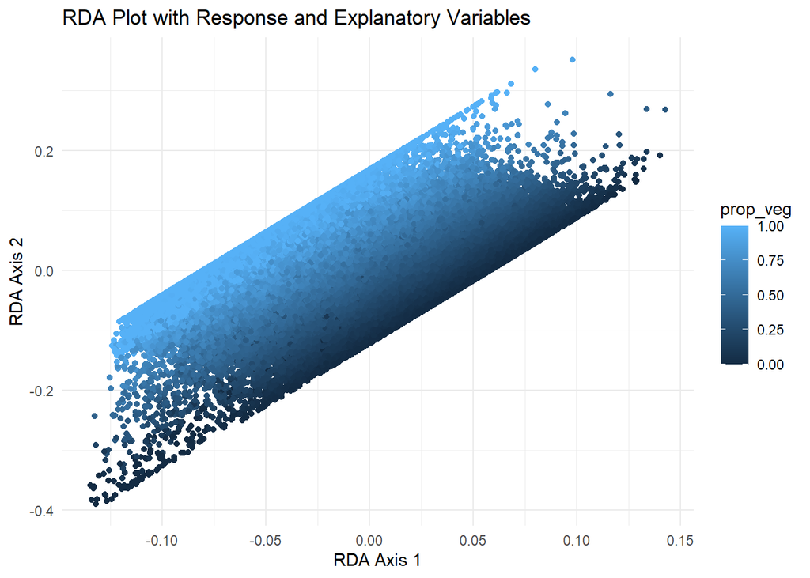

```r
ggplot() +
  geom_point(data = as.data.frame(cdata), aes(x = RDA1, y = PC1, color = prop_veg)) +
  theme_minimal() +
  labs(title = "RDA Plot with Response and Explanatory Variables", x = "RDA Axis 1", y = "RDA Axis 2")
```

That solves my problem :) now we know for this. Lets do a plot to see where the vegetation needs are met and where we need more to supply for the service

```
##
##   1-1   1-2   1-3   2-1   2-2   2-3   3-1   3-2   3-3
## 40548   653    51 13203  8585  2902 11392 34119 12047
```

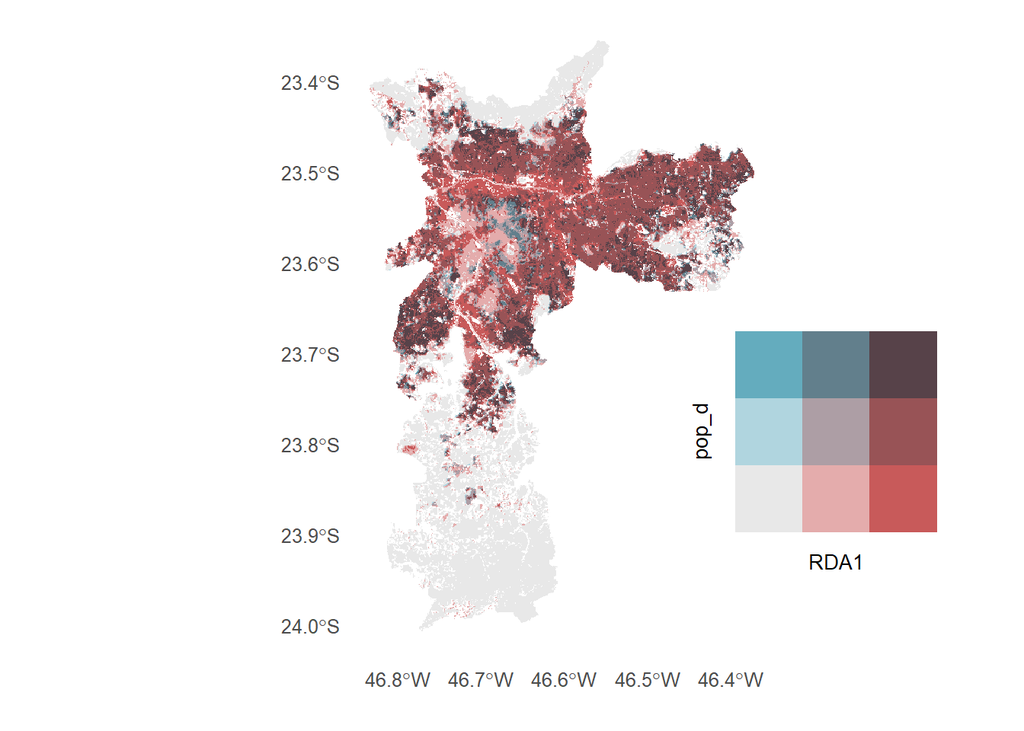

```r
plot_bi_map(cdata, "RDA1", "pop_d")
```

```r
sub_data <- subset(as.data.frame(cdata), select = c(RDA1, pop_d))
sub_data <- bi_class(sub_data, x = RDA1, y = pop_d, style = "fisher")
```

[figure not shown]

```r
cdata$biclass <- sub_data$bi_class

supplied <- cdata[cdata$biclass != "1-1",]
ggplot(supplied) +
  geom_sf(aes(fill = SUVI), color = NA) +  # Fill grid cells based on RDA1 scores
  scale_fill_viridis_c() +  # Use a continuous color scale
  labs(title = "Spatial Distribution of RDA Axis 1 Scores") +
  theme_minimal()
```

As expected, most of the population does not experience the relief, and the ones that do are in a very specific region in the center of the city

## Space

Still, there is a lot of spatial autocorrelation not accounted for.